# Mean target achievement (MTA) indicator

Overall latest MTA

0.499

Change since 2018

0.021

Number of species and habitats

2051

**Features**

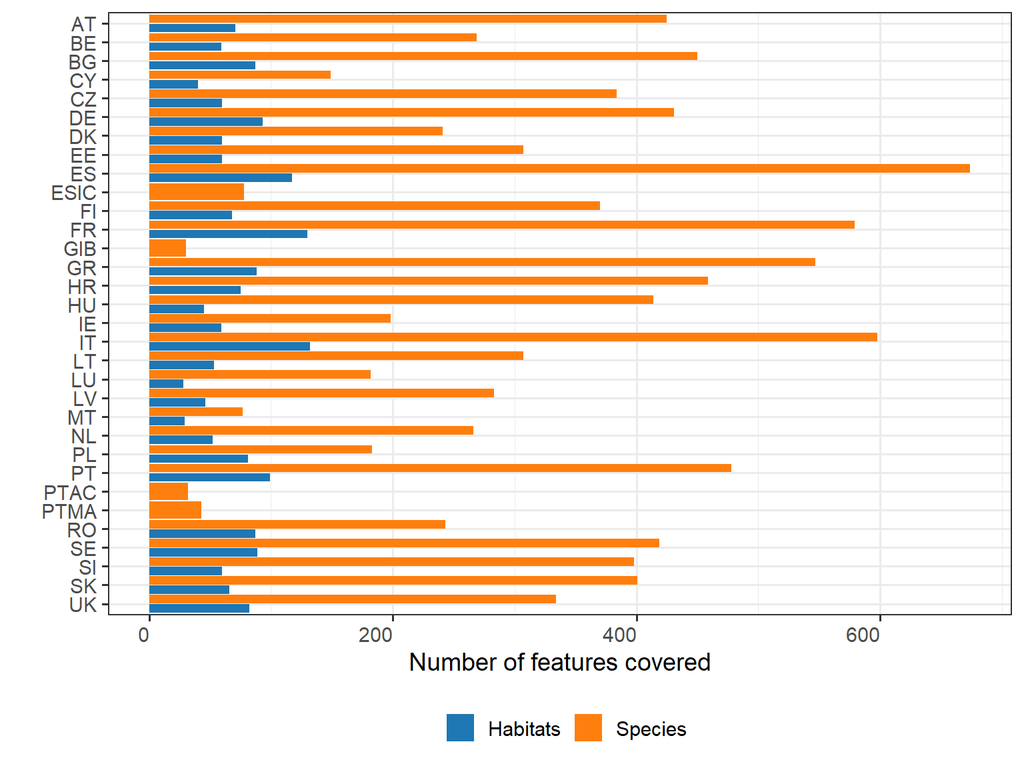

**Coverage**

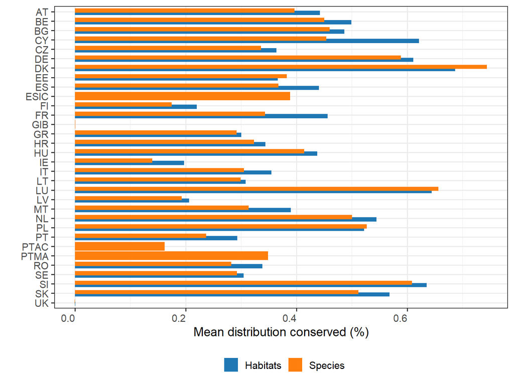

**Targets**

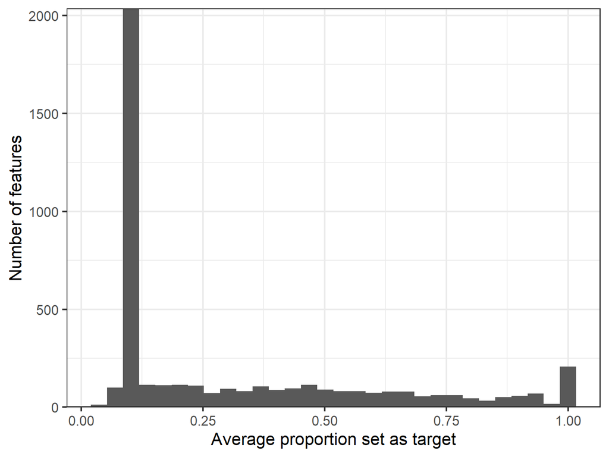

**Conservation areas**

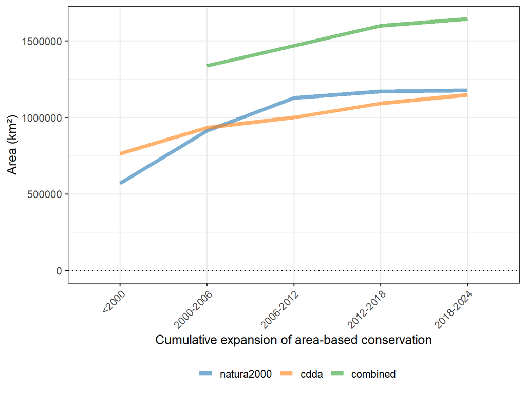

**Overall**

[interactive chart not shown]

**Area type**

[interactive chart not shown]

**By article**

[interactive chart not shown]

**By area type and article**

[interactive chart not shown]

Download indicator factsheet

[interactive chart not shown]

Methodology

The current calculation of the MTA is feasible every 6 years and can also be further refined to account for land-cover and land-use change, for example using data from the Corine Accounting layer. Furthermore, for comparability data on EEA reporting is used, although more higher resolved species distribution data (such as those produced by the NaturaConnect project) are slowly becoming available.

Data

As data sources we relied for this demonstration on the officially used Article 12 (‘Birds directive’) and Article 17 (‘Habitats directive’) reporting data made by Member states (MS). Sensitive species were also included in those calculations and it is because of this reason that the input data can not be shared publicly.

As conservation areas we relied on the [Natura2000 geopackage](https://www.eea.europa.eu/data-and-maps/data/natura-14/natura-2000-spatial-data) (last updated in April 2024).

Note

It should be highlighted that the MTA is calculate based on the official Reporting by EU Memberstates as part of Article 12 and Article 17. Thus the targets, and conserved distribution and total distribution reflect the distribution of a species or habitat occurring in the European union only (despite some species likely also occurring elsewhere).

A more comprehensive version of the MTA will be calculated as part of the [NaturaConnect](https://naturaconnect.eu/) project, which however does not use official European data, but specifically created data and targets for this purpose.

References

Adams VM, Visconti P, Graham V, Possingham HP (2021) Indicators keep progress honest: A call to track both the quantity and quality of protected areas. One Earth 4:901–906. https://doi.org/10.1016/j.oneear.2021.06.014

Jantke K, Kuempel CD, McGowan J, et al (2019) Metrics for evaluating representation target achievement in protected area networks. Diversity and Distributions 25:170–175. https://doi.org/10.1111/ddi.12853

Jung M, Arnell A, Lamo X de, et al (2021) Areas of global importance for conserving terrestrial biodiversity, carbon and water. Nature Ecology & Evolution 5:1499–1509. https://doi.org/10.1038/s41559-021-01528-7

Rodrigues ASL, Akçakaya HR, Andelman SJ, et al (2004) Global gap analysis: Priority regions for expanding the global protected-area network. BioScience 54:1092. https://doi.org/10.1641/0006-3568(2004)054[1092:GGAPRF]2.0.CO;2

Visconti P, Butchart SHM, Brooks TM, et al (2019) Protected area targets post-2020. Science 364:eaav6886. https://doi.org/10.1126/science.aav6886

Data availability

The calculated MTA indicator values have been made openly available on a Zenodo repository in various combinations. The calculated values are provides as is, and the author and NaturaConnect project take no liability for errors or misinterpretations.

[Download EU MTA indicator values](https://doi.org/10.5281/zenodo.14196503)

Current version: 01

**Please check the repository regularly for updated versions.**

Methodology

[figure not shown]

NaturaConnect receives funding under the European Union’s Horizon Europe research and innovation programme under grant agreement number 101060429.

To find out more about our project, please visit our [homepage](https://naturaconnect.eu/).

The MTA indicator calculation and the creation of this dashboard has been led by **Martin Jung** (IIASA) as part of the WP7 of the NaturaConnect project. The information here is provided free of charge and the project takes no responsibility for errors or misuse.